# Tennis Grand Slam

ALMHDIE Hatim

01/10/2019

```r
player_dob <- readr::read_csv("https://raw.githubusercontent.com/rfordatascience/tidytuesday/master/data/2019/2019-04-09/player_dob.csv")
grand_slams <- readr::read_csv("https://raw.githubusercontent.com/rfordatascience/tidytuesday/master/data/2019/2019-04-09/grand_slams.csv")
grand_slam_timeline <- readr::read_csv("https://raw.githubusercontent.com/rfordatascience/tidytuesday/master/data/2019/2019-04-09/grand_slam_timeline.csv")
library(tidyverse)
```

# INTRODUCTION

Au tennis, le Grand Chelem est le fait de remporter la même année, les quatre tournois majeurs du circuit international organisé par la Fédération internationale de tennis, à savoir : -l’Open d’Australie à Melbourne (type de surface : dur), -Roland-Garros à Paris (type de surface : terre battue), -le tournoi de Wimbledon à Londres (type de surface : gazon), -l’US Open à New York (type de surface : dur). Ces quatre tournois majeurs, appelés en conséquence « tournois du Grand Chelem », sont les plus prestigieux et les plus difficiles à gagner sur le circuit professionnel. Ils se déroulent en effet pour chacun sur deux semaines consécutives. Pour le simple messieurs, chaque tour se joue en trois sets gagnants, contre deux sets gagnants pour les autres épreuves.

# OBSERVATION 1

Quel est l’age d’un joueur de tennis lors de son premier titre de grand slam par tranche d’age ?

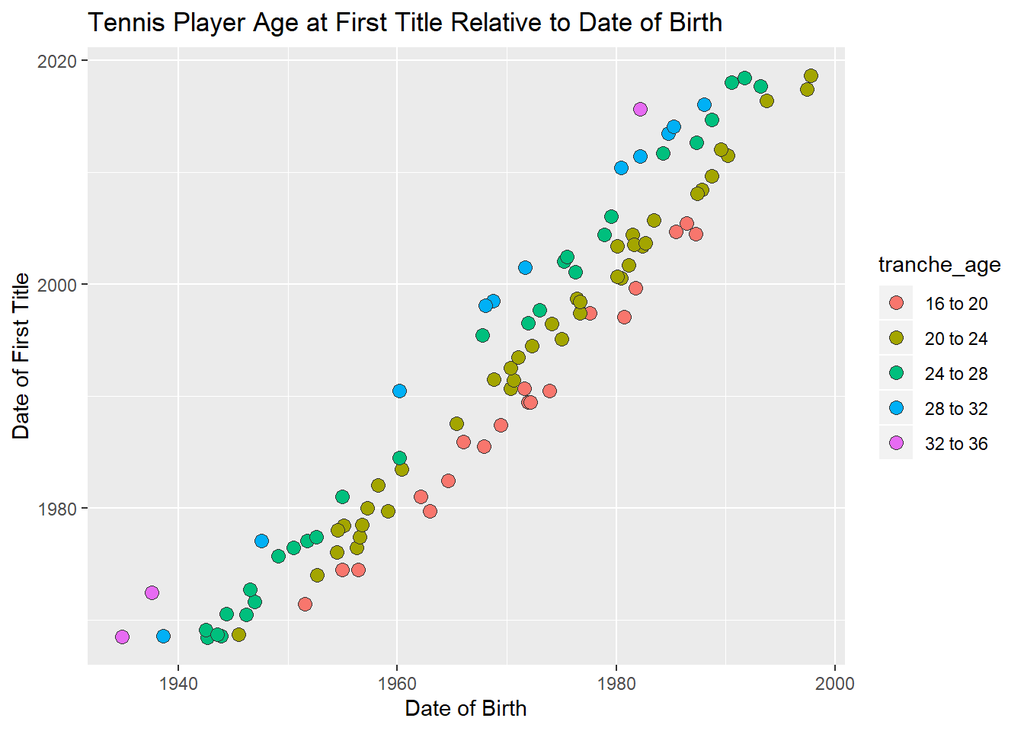

on s’apercoit que les joueurs de tennis gagnent leur grand slam entre 20 et 24 ans majoritairement suivis de ceux ayant entre 24 et 28 ans. On peut en déduire que rare sont les joueurs qui gagnent leur premier titre entre 32 et 36 ans.

# OBSERVATION 2

quel est l’age moyen des joueurs de tennis lors de leur premier titre de grand chelem par sexe ?

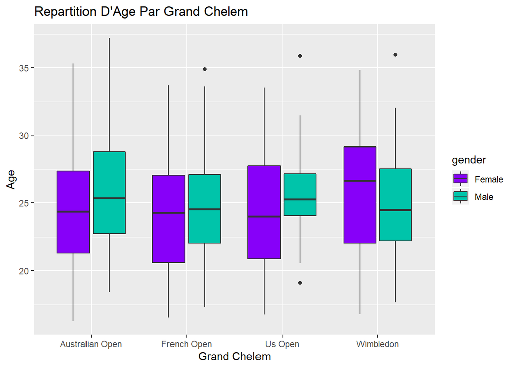

```r
# Calculate age

age <- player_dob %>%

  select(name, date_of_birth) %>%

  inner_join(grand_slams, by = "name") %>%

  mutate(age = as.numeric(difftime(tournament_date, date_of_birth, unit = "days"))/365)

# Boxplot of player ages by tournament

age %>%

  mutate(grand_slam = str_to_title(str_replace(grand_slam, "_", " "))) %>%

  ggplot(aes(x =grand_slam, y = age, fill = gender)) +

  geom_boxplot() +

  scale_fill_manual(values = c('#8700F9', '#00C4AA')) +

  labs(x = "Grand Chelem",

       y = "Age",

       title = "Repartition D'Age Par Grand Chelem")
```

# OBSERVATION 3

Quels sont les joueurs de tennis ayant remporté le plus de grand chelem de 1968 à nos jours ?

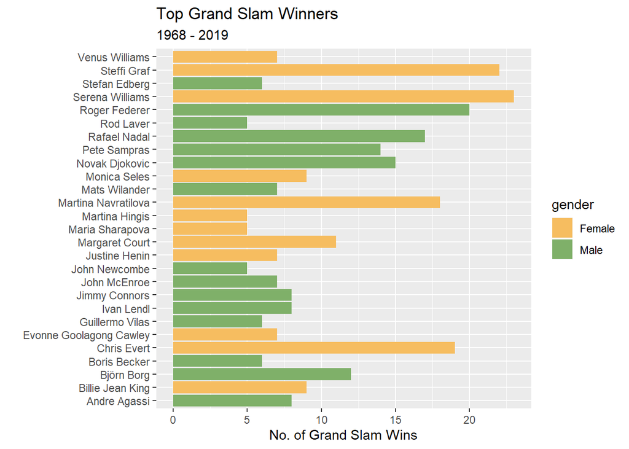

```r
# Plot Top Winners

grand_slams %>%
  group_by(gender) %>%
count(name, sort = TRUE) %>%

add_count(name, wt = n) %>%

filter(n >=5) %>%
mutate(name = fct_reorder(name, n, sum)) %>%

ggplot(aes(name, n, fill = gender )) +

geom_col() +

  scale_fill_manual(values = c('#F6BD60', '#7FB069', '#548687')) +
  coord_flip() +

labs(x = "",

     y = "No. of Grand Slam Wins",

     title = "Top Grand Slam Winners ",

     subtitle = "1968 - 2019")
```

Federer est le troisieme athlète à passer la barre mythique des 20 tournois du Grand Chelem depuis 1968. Les deux autres sont des joueuses : Serena Williams (23) et Steffi Graf (22).Le top 2 chez les hommes est rafael nadal avec 17 titres de grand chelem.